# Reinforcement Learning

Kannan Singaravelu, CQF

# Reinforcement Learning

Reinforcement learning (RL) is one of three machine learning paradigms, alongside supervised learning and unsupervised learning. RL differs from supervised learning as it focus on finding a balance between exploration and exploitation.

In this approach, the (algorithm) agents take actions in an environment in order to maximize its cumulative reward. The environment is typically stated in the form of a Markov decision process (MDP), because many reinforcement learning algorithms for this context utilize dynamic programming techniques.

MDP is a discrete-time stochastic control process and provides a mathematical framework for modeling decision making in situations where outcomes are partly random and partly under the control of a decision maker. Such processes are useful in optimization problems solved via dynamic programming and reinforcement learning.

RL framework is extremely promising in trading and investment management. Currently RL is mostly a research area and hasn’t yet had significant practical successes beyond games. However, it’s an idea whose time has come.

## Fundamental Notions

Following are some of the fundamental notions of the RL

[figure not shown]

**Environment :** The world through which agents moves. The environment defines the problem at hand. For example, the environment can be a financial market to be traded in.

**State :** Current condition returned by the environment. A state subsumes all relevant parameters that describe the current state of the environment. In a financial market, this might include current and historical price levels or financial indicators such as moving averages, macroeconomic variables, and so on.

**Agent :** The RL algorithm that learns from the exploration and exploitation. Agent subsumes all elements of the RL algorithm that interacts with the environment and learns from these interactions. In a financial context, the agent could represent a trader placing bets on rising or falling markets.

**Action :** All possible steps that the agent can take from a (limited) set of allowed actions. In a financial market, going long or short could be admissible actions.

**Reward :** An instant return from the environment to appraise the last action. In a financial context, profit (or loss) is a standard reward.

**Policy :** The approach the agent uses to determine the next action based on the current state. In a financial context, a trading bot that observes three price increases in a row might decide to buy the market.

**Value :** The expected long-term return with discount, as opposed to short-term rewards. For a financial trading bot, this might be the expected accumulated trading profit.

**Episode :** The set of steps from the initial state of the environment until success is achieved or failure is observed. In the financial world, this might be from the beginning of the year to the end of the year or to bankruptcy.

## RL Algorithms

[figure not shown]

A non-exhaustive, but useful taxonomy of algorithms in modern RL [1]

## Markov Decision Process

MDP is the mathematical formulation of the RL problem where it uses the Markov property where the current state completely characterises the state of the world and is defined by $(S, A, R, P, \gamma)$

where,

$S$ : set of possible states  
$A$ : set of possible actions  
$R$ : distribution of reward given (state, action) pair  
$P$: transition probability i.e, distribution over next state given (state, action) pair  
$\gamma$ : discount factor

The MDP process is as follows,

- Environment samples initial state at $S_0 ~ p(s_0)$ at $t=0$
- Then, for $t=0$ until done:
  - agent selects action $a_t$
  - environment samples reward $r_t ~ R(.|s_t, a_t)$
  - environment samples next state $s_{t+1} ~ P(.|s_t, a_t)$
  - agent receives reward $r_t$ and next state $s_{t+1}$
- Policy $\pi$ is a function from $S$ to $A$ that specifies what action to take in each state
- Objective: find policy $\pi^*$ or value $Q^*$ that maximizes cumulative discounted reward: $\sum_{t>0} \gamma^tr_t$

## Shortest Path Problem

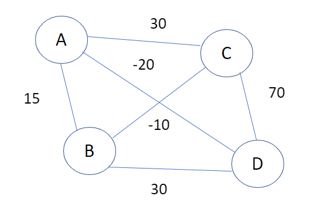

The markov decision process is used to find the shortest path between A and D with maximum reward. In this example,

- Set of states are denoted by nodes {A,B,C,D}
- Action is to traverse from one node to another
- Reward is the cost represented by each edge
- Policy is the path taken to reach the destination {A >> C >> D}